# Statistical Inference Course Project - Simulation Exercise

Prykhodko Pavel

June 6, 2018

## Overview

In this simulation exercise we’ll look into the distribution of averages of 40 exponentials in R and compare it with the Central Limit Theorem.

In particular, we will illustrate:  
1. Sample mean and theoretical mean  
2. Sample variance and theoretical variance  
3. Normality of the distribution

To reproduce this exercise you will need *ggplot2* library.  
To get the same results you can set the seed to *87310*.

```r
library(ggplot2)
set.seed(87310)
```

## Simulation

We will simulate 1000 exponential distributions with R function rexp(n, lambda).  
lambda will be 0.2 for all our simulations.  
The mean of the exponential distribution is 1/lambda, and the standard deviation is also 1/lambda.

Let’s make our simulations and store them into a matrix:

```r
lambda <- 0.2
sampleSize <- 40
simulationsCount <- 1000
simulations <- rexp(simulationsCount * sampleSize, rate = lambda)
simulationsMatrix <- matrix(simulations, simulationsCount, sampleSize)
```

## Sample Mean versus Theoretical Mean

The exponential distribution mean is 1/lambda, so for this distribution theoretical mean should be `1 / lamba(0.2) = 5`.  
Let’s calculate the means of our simulations.

```r
simulationsMean <- rowMeans(simulationsMatrix)
sampleMean <- mean(simulationsMean)
theoreticalMean <- (1 / lambda)
```

We will plot the means histogram and draw a sample mean with green line and a theoretical mean with red line on that plot for comparison.

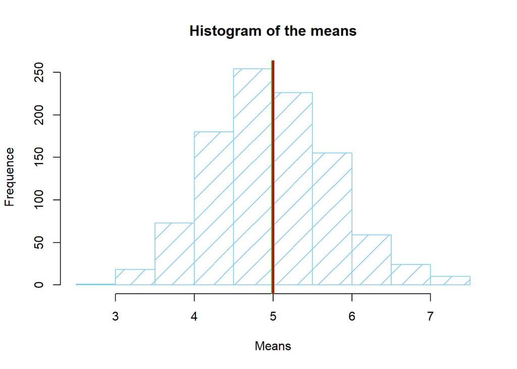

```r
hist(
  simulationsMean,
  xlab = "Means",
  ylab = "Frequence",
  main = "Histogram of the means",
  col = "skyblue",
  density = 5
)
abline(v = sampleMean, lwd = 3, col = "green2")
abline(v = theoreticalMean, lwd = 3, col = "red3")
```

As you see - the red and green lines are nearly same, because of sample mean `mean(simulationsMatrix)` is 4.9886958 and that is very close to 5.

## Sample Variance versus Theoretical Variance

Let’s compare sample and theoretical variances.

```r
theoreticalVariance <- ((1 / lambda) ^ 2) / sampleSize
sampleVariance <- var(simulationsMean)
```

Variance is `((1 / lambda) ^ 2) / sampleSize`, so theoretical one will be 0.625.  
The variance of our sample `var(simulationsMean)` is 0.599169.  
That is not as good as in previous comparison, but still very close.

## Distribution

In this question we need to demonstrate, that our simulations distribution is approximately normal.  
The best way to do it is to draw a sample distribution and a normal distribution lines in one plot.  
We will mark distributions with green line for sample and red line for normal as we did in the first plot.

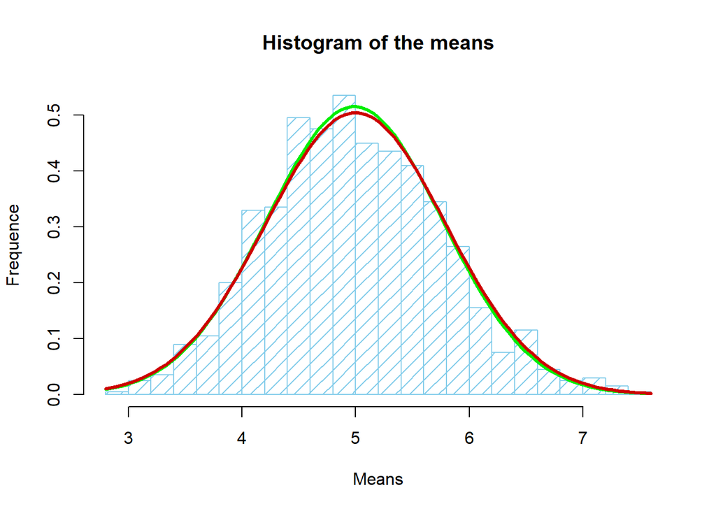

```r
hist(
  simulationsMean,
  xlab = "Means",
  ylab = "Frequence",
  main = "Histogram of the means",
  col = "skyblue",
  breaks = 20,
  prob = TRUE,
  density = 10
)

curve(
  dnorm(x, mean = sampleMean, sd = sqrt(sampleVariance)),
  col = "green2", lwd = 3, add = TRUE
)
curve(
  dnorm(x, mean = theoreticalMean, sd = sqrt(theoreticalVariance)),
  col = "red3", lwd = 3, add = TRUE
)
```

Again, red and green curves are close, so we can make a conclusion that distribution is approximately normal.